# Children - Study 2 - Results

# AOI Looking

Now we’ll re-calculate the percentages so the denominator is based on total looking time. All AOIs should sum up to 100% for each trial and each baby. Next let’s make a boxplot of all AOIs. Interesting, definitely more MidFaceBottom focus here than we had with babies, but also more distribution too.

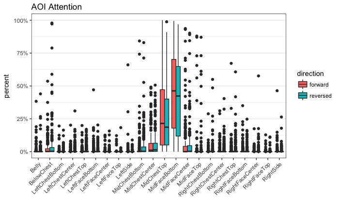

```r
# Recalculate percent
kids <- kids %>%
  select(-percent) %>%
  group_by(name, lang, age, direction, story, mark, trial, repetition) %>%
  mutate(totalsec = sum(secs)) %>%
  group_by(name, lang, age, direction, story, mark, trial, repetition, aoi) %>%
  summarise(percent = secs/totalsec)
# Boxplot
kids %>%
  ggplot(aes(x = aoi, y = percent, fill = direction)) +
  geom_boxplot() +
  ggtitle("AOI Attention") +
  theme_bw() +
  xlab("") +
  theme(axis.text.x = element_text(angle=45, hjust = 1),
        panel.grid.major.x = element_blank()) +
  scale_y_continuous(labels = scales::percent, limits = c(0,1))
```

It appears two important AOIs are MidChestTop and MidFaceBottom. Let’s look again only at midline AOIs:

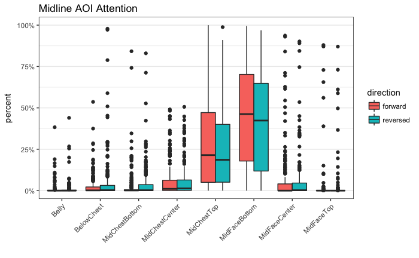

```r
midline = c("Belly","BelowChest","MidChestBottom","MidChestCenter","MidChestTop",
            "MidFaceBottom","MidFaceCenter","MidFaceTop")
kids %>%
  filter(aoi %in% midline) %>%
  ggplot(aes(x = aoi, y = percent, fill = direction)) +
  geom_boxplot() +
  ggtitle("Midline AOI Attention") +
  theme_bw() +
  xlab("") +
  theme(axis.text.x = element_text(angle=45, hjust = 1),
        panel.grid.major.x = element_blank()) +
  scale_y_continuous(labels = scales::percent, limits = c(0,1))
```

I’m going to run linear models with only MidChestTop or MidFaceBottom, and see what happens. No age interactions.

**MidChestTop:**

- No effect of age.
- No effect of language.
- *Weak* effect of direction (p = 0.084) - reversed means they look ~ 4.7% less at midchesttop.
- No language X direction interaction.

**MidFaceBottom:**

- No effect of age.
- Significant effect of language (p = 0.004) - SE look at MidFaceBottom +19% more than NSE children
- No effect of direction.
- No language X direction interaction.

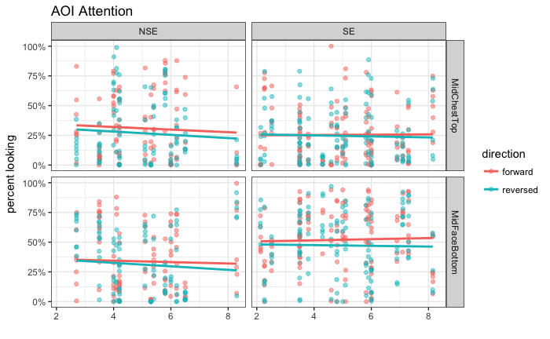

```r
kids %>%
  filter(aoi %in% c("MidFaceBottom","MidChestTop")) %>%
  ggplot(aes(x = age, y = percent, color = direction, fill = direction)) +
  geom_jitter(alpha = 0.5) +
  geom_smooth(method = "lm", se = FALSE) +
  scale_y_continuous(limits = c(0,1), labels = percent) +
  theme_bw() +
#  theme(panel.grid.major.x = element_blank()) +
  facet_grid(aoi ~ lang) +
  ggtitle("AOI Attention") +
  xlab("") +
  ylab("percent looking")
```

```r
midchesttop_lm <- lmer(percent ~ age + lang * direction + (1|name) + (1|story), data = filter(kids, aoi == "MidChestTop"))
summary(midchesttop_lm)
```

```
Linear mixed model fit by REML. t-tests use Satterthwaite's method ['lmerModLmerTest']
Formula: percent ~ age + lang * direction + (1 | name) + (1 | story)
   Data: filter(kids, aoi == "MidChestTop")

REML criterion at convergence: -108

Scaled residuals:
    Min      1Q  Median      3Q     Max
-2.0759 -0.6139 -0.1635  0.5257  3.4431

Random effects:
 Groups   Name        Variance  Std.Dev.
 name     (Intercept) 0.0236538 0.15380
 story    (Intercept) 0.0001076 0.01037
 Residual             0.0375729 0.19384
Number of obs: 471, groups:  name, 35; story, 8

Fixed effects:
                           Estimate Std. Error         df t value Pr(>|t|)
(Intercept)                0.332735   0.097931  33.690951   3.398  0.00176 **
age                       -0.004869   0.017507  32.325737  -0.278  0.78269
langSE                    -0.067047   0.058495  39.321521  -1.146  0.25863
directionreversed         -0.047327   0.027264 337.964771  -1.736  0.08350 .
langSE:directionreversed   0.049457   0.036436 348.960799   1.357  0.17554
---
Signif. codes:  0 ‘***’ 0.001 ‘**’ 0.01 ‘*’ 0.05 ‘.’ 0.1 ‘ ’ 1

Correlation of Fixed Effects:
            (Intr) age    langSE drctnr
age         -0.892
langSE      -0.360  0.022
dirctnrvrsd -0.142  0.003  0.235
lngSE:drctn  0.109 -0.004 -0.310 -0.751
```

```r
#ggcoef(midchesttop_lm)
midfacebottom_lm <- lmer(percent ~ age + lang * direction + (1|name) + (1|story), data = filter(kids, aoi == "MidFaceBottom"))
summary(midfacebottom_lm)
```

```
Linear mixed model fit by REML. t-tests use Satterthwaite's method ['lmerModLmerTest']
Formula: percent ~ age + lang * direction + (1 | name) + (1 | story)
   Data: filter(kids, aoi == "MidFaceBottom")

REML criterion at convergence: 27

Scaled residuals:
    Min      1Q  Median      3Q     Max
-2.6917 -0.6530 -0.0125  0.7073  2.5459

Random effects:
 Groups   Name        Variance Std.Dev.
 name     (Intercept) 0.025608 0.16003
 story    (Intercept) 0.001334 0.03652
 Residual             0.050261 0.22419
Number of obs: 471, groups:  name, 35; story, 8

Fixed effects:
                           Estimate Std. Error         df t value Pr(>|t|)
(Intercept)                0.359107   0.104202  34.707523   3.446  0.00151 **
age                       -0.005518   0.018451  32.184210  -0.299  0.76684
langSE                     0.188369   0.062415  41.101136   3.018  0.00436 **
directionreversed         -0.005451   0.032290 418.172403  -0.169  0.86602
langSE:directionreversed  -0.049417   0.043090 421.681027  -1.147  0.25210
---
Signif. codes:  0 ‘***’ 0.001 ‘**’ 0.01 ‘*’ 0.05 ‘.’ 0.1 ‘ ’ 1

Correlation of Fixed Effects:
            (Intr) age    langSE drctnr
age         -0.883
langSE      -0.361  0.021
dirctnrvrsd -0.158  0.002  0.266
lngSE:drctn  0.122 -0.003 -0.345 -0.762
```

```r
#ggcoef(midfacebottom_lm)
# Bar chart
# babies %>%
#   filter(aoi %in% c("MidFaceBottom","MidChestTop")) %>%
#   group_by(agegroup, lang, direction, name, aoi) %>%
#   summarise(percent = mean(percent)) %>% # gets average looking percent for each baby
#   group_by(agegroup, lang, direction, aoi) %>%
#   summarise(mean_percent = mean(percent), # gets group averages
#             count = n(),
#             sd = sd(percent),
#             se = sd/sqrt(count)) %>%
#   ggplot(aes(x = lang, y = mean_percent, fill = direction)) +
#   geom_col(position = "dodge") +
#   geom_errorbar(aes(ymin = mean_percent - se, ymax = mean_percent + se),
#                 position = position_dodge(width = 0.9), width = 0.25) +
#   scale_y_continuous(limits = c(0,1), labels = percent) +
#   theme_minimal() +
#   theme(panel.grid.major.x = element_blank()) +
#   facet_grid(aoi ~ agegroup) +
#   ggtitle("Video Attention") +
#   xlab("") +
#   ylab("percent looking")
```

# Face-Chest Ratio

Next, we’ll define a Face-Chest Ratio (FCR) such that:

1. MidFaceCenter, MidFaceBottom = Face
2. MidChestTop, MidChestCenter, MidChestBottom, BelowChest = Chest
3. FCR = face - chest / face + chest

We did not include Belly or MidFaceTop because of very low looking rates according to the boxplots above.

```r
kids_fcr <- kids %>%
  spread(aoi,percent) %>%
  group_by(name, age, lang, direction, story, repetition) %>%
  summarise(face = sum(MidFaceCenter, MidFaceBottom, na.rm = TRUE),
         chest = sum(MidChestTop, MidChestCenter, MidChestBottom, BelowChest, na.rm = TRUE),
         fcr = (face - chest) / (face + chest))
# Table of means
kids_fcr %>%
  group_by(lang, direction, name) %>%
  summarise(fcr = mean(fcr)) %>% # gets average looking percent for each baby
  group_by(lang, direction) %>%
  summarise(mean_fcr = mean(fcr), # gets group averages
            count = n(),
            sd = sd(fcr),
            se = sd/sqrt(count)) %>%
  select(-sd) %>%
  print()
```

| lang | direction | mean_fcr | count | se |
| --- | --- | --- | --- | --- |
| NSE | forward | -0.04555596 | 15 | 0.14457318 |
| NSE | reversed | -0.11422680 | 15 | 0.13482772 |
| SE | forward | 0.30254227 | 20 | 0.07979049 |
| SE | reversed | 0.19078700 | 20 | 0.07924227 |

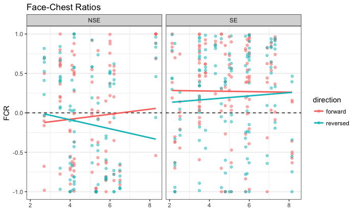

```r
# Plot
ggplot(kids_fcr, aes(x = age, y = fcr, color = direction, fill = direction)) +
  geom_hline(yintercept = 0, linetype = "dashed") +
  geom_jitter(alpha = 0.5) +
  geom_smooth(method = "lm", se = FALSE) +
  scale_y_continuous(limits = c(-1,1)) +
  theme_bw() +
  theme(panel.grid.major.x = element_blank()) +
  facet_grid(. ~ lang) +
  ggtitle("Face-Chest Ratios") +
  xlab("") +
  ylab("FCR")
```

```r
# Bar chart
# babies_fcr %>%
#   group_by(agegroup, lang, direction, name) %>%
#   summarise(fcr = mean(fcr)) %>% # gets average looking percent for each baby
#   group_by(agegroup, lang, direction) %>%
#   summarise(mean_fcr = mean(fcr), # gets group averages
#             count = n(),
#             sd = sd(fcr),
#             se = sd/sqrt(count)) %>%
#   ggplot(aes(x = lang, y = mean_fcr, fill = direction)) +
#   geom_col(position = "dodge") +
#   geom_errorbar(aes(ymin = mean_fcr - se, ymax = mean_fcr + se),
#                 position = position_dodge(width = 0.9), width = 0.25) +
#   scale_y_continuous(limits = c(-1,1)) +
#   theme_minimal() +
#   theme(panel.grid.major.x = element_blank()) +
#   facet_wrap("agegroup") +
#   ggtitle("Face-Chest Ratios") +
#   xlab("") +
#   ylab("FCR")
```

What will a linear mixed model tell us? (with no age interactions)

- No effect of age. Interesting. Maybe just becuase we don’t have that many babies.
- Effect of language: SE babies have overall +0.36 FCR than NSE babies (p = 0.03). SE looks at the face more than the chest.
- No effect of direction. Interesting.
- No interaction. Interesting.

```r
fcr_lm <- lmer(fcr ~ age + lang * direction + (1|name) + (1|story), data = kids_fcr)
summary(fcr_lm)
```

```
Linear mixed model fit by REML. t-tests use Satterthwaite's method ['lmerModLmerTest']
Formula: fcr ~ age + lang * direction + (1 | name) + (1 | story)
   Data: kids_fcr

REML criterion at convergence: 747.9

Scaled residuals:
     Min       1Q   Median       3Q      Max
-3.04087 -0.55798  0.04156  0.68150  2.93235

Random effects:
 Groups   Name        Variance Std.Dev.
 name     (Intercept) 0.17809  0.4220
 story    (Intercept) 0.01392  0.1180
 Residual             0.22797  0.4775
Number of obs: 471, groups:  name, 35; story, 8

Fixed effects:
                           Estimate Std. Error         df t value Pr(>|t|)
(Intercept)               -0.051211   0.268645  34.803179  -0.191   0.8499
age                       -0.001861   0.047533  32.187271  -0.039   0.9690
langSE                     0.357443   0.157942  38.316970   2.263   0.0294 *
directionreversed         -0.047553   0.069424 433.299141  -0.685   0.4937
langSE:directionreversed  -0.068533   0.092601 434.179175  -0.740   0.4596
---
Signif. codes:  0 ‘***’ 0.001 ‘**’ 0.01 ‘*’ 0.05 ‘.’ 0.1 ‘ ’ 1

Correlation of Fixed Effects:
            (Intr) age    langSE drctnr
age         -0.882
langSE      -0.355  0.022
dirctnrvrsd -0.132  0.001  0.227
lngSE:drctn  0.102 -0.002 -0.293 -0.766
```

```r
#ggcoef(fcr_lm)
```

# Visualizing Reversal Effect

I want to try to visualize reversal effects a different way. Maybe this.

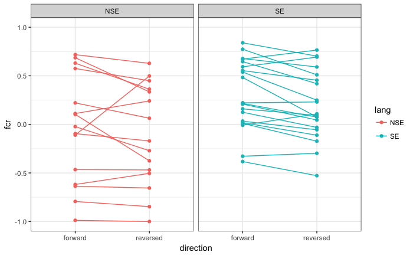

```r
# Get participant-level data
kids_fcr2 <- kids_fcr %>%
  group_by(name, age, lang, direction) %>%
  summarise(fcr = mean(fcr))
# reversal_effect_lm <- lmer(fcr ~ age + lang * direction + (1|name), data = kids_fcr2)
# summary(reversal_effect_lm)
ggplot(kids_fcr2, aes(x = direction, y = fcr, color = lang, fill = lang)) +
  geom_point() +
  geom_line(aes(group = name)) +
  facet_grid(. ~ lang) +
  scale_y_continuous(limits = c(-1,1)) +
  theme_bw()
```

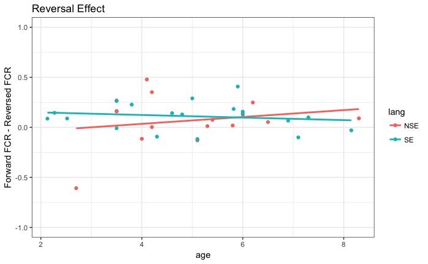

```r
# Get participant-level data
kids_fcr3 <- kids_fcr2 %>%
  spread(direction, fcr) %>%
  group_by(name, age, lang) %>%
  summarise(diff = forward - reversed)
ggplot(kids_fcr3, aes(x = age, y = diff, color = lang)) +
  geom_point() +
  geom_smooth(method = "lm", se = FALSE) +
  scale_y_continuous(limits = c(-1,1)) +
  theme_bw() +
  ggtitle("Reversal Effect") +
  ylab("Forward FCR - Reversed FCR")
```

And within-subjects variation here:

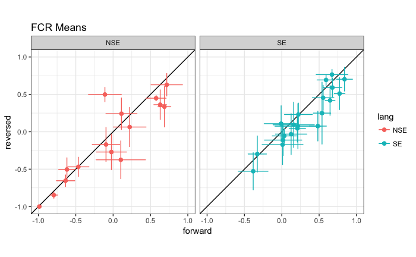

```r
# First get the mean of each trial, THEN the participant-level means
within_subjects <- kids_fcr %>%
  group_by(name, lang, direction, story, repetition) %>%
  summarise(fcr = mean(fcr, na.rm = TRUE),
            count = n()) %>%
  group_by(name, lang, direction) %>%
  summarise(mean = mean(fcr, na.rm = TRUE),
            se = sd(fcr, na.rm = TRUE)/sqrt(n()),
            count = n())
# Then spread out mean and SE columns by direction
within_subjects_means <- within_subjects %>%
  select(-se, -count) %>%
  spread(direction, mean, sep = "_")
within_subjects_se <- within_subjects %>%
  select(-mean, -count) %>%
  spread(direction, se, sep = "SE")
within_subjects <- left_join(within_subjects_means, within_subjects_se, by = c("name","lang"))
# Now let's plot
lims <- c(-1,1)
within_subjects %>%
  ggplot(aes(x = direction_forward, y = direction_reversed, color = lang)) +
    geom_abline() +
  geom_point(size = 2) +
  geom_errorbar(aes(ymin=direction_reversed-directionSEreversed, ymax=direction_reversed+directionSEreversed)) +
  geom_errorbarh(aes(xmin=direction_forward-directionSEforward, xmax=direction_forward+directionSEforward)) +
  theme_bw() +
  theme(aspect.ratio = 1) +
  scale_x_continuous("forward", limits = c(-1,1)) +
  scale_y_continuous("reversed", limits = c(-1,1)) +
  ggtitle("FCR Means") +
  facet_wrap("lang")
```

And a classic box/error plot with age collapsed.

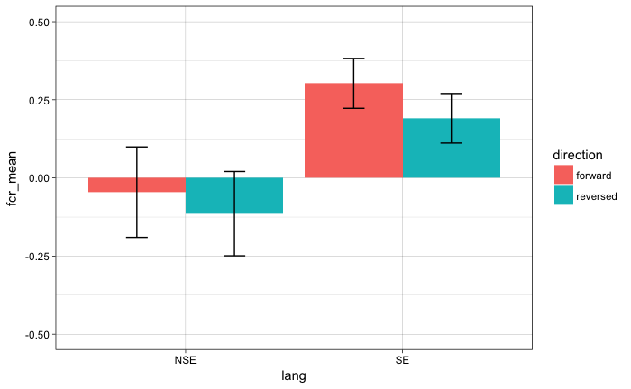

```r
kids_fcr2 %>%
  group_by(lang, direction) %>%
  summarise(fcr_mean = mean(fcr),
            sd = sd(fcr),
            n = n(),
            se = sd/sqrt(n)) %>%
  ggplot(aes(x = lang, y = fcr_mean, fill = direction)) +
  geom_bar(stat = "identity", position = position_dodge()) +
  geom_errorbar(aes(ymin = fcr_mean-se, ymax = fcr_mean+se), position = position_dodge(0.9), width = 0.2) +
  scale_y_continuous(limits = c(-0.5, 0.5)) +
  theme_linedraw()
```

# Heat Maps

And now heat maps!

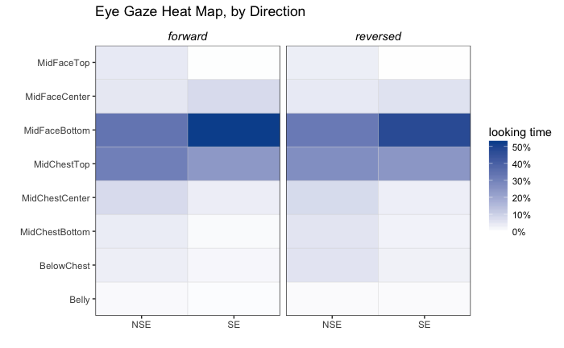

```r
heatmap_kids <- kids %>%
  filter(aoi %in% midline) %>%
  ungroup() %>%
  group_by(lang, name, direction, aoi) %>%
  summarise(percent = mean(percent, na.rm=TRUE)) %>%
  group_by(lang, direction, aoi) %>%
  summarise(percent = mean(percent, na.rm=TRUE)) %>%
  ungroup() %>%
  mutate(aoi = factor(aoi, levels = c("Belly","BelowChest","MidChestBottom","MidChestCenter","MidChestTop",
            "MidFaceBottom","MidFaceCenter","MidFaceTop")))
ggplot(heatmap_kids, aes(x = lang, y = aoi)) +
  geom_tile(aes(fill=percent),color="lightgray",na.rm=TRUE) +
#  scale_fill_viridis(option = "viridis", direction=-1, limits = c(0,.7), labels = percent, name = "looking time") +
    scale_fill_gradient(low = "#ffffff", high = "#08519c", space = "Lab", limits = c(0,.52), labels = percent, name = "looking time", na.value = "grey50") +
  theme_bw() +
  theme(strip.text.x = element_text(size = 11, color = "black", face = "italic"),
        strip.background = element_rect(colour = "white", fill = "white"),
        panel.grid.major = element_line(color = "white")) +
  facet_grid(. ~ direction) +
  ylab("") + xlab("") + ggtitle("Eye Gaze Heat Map, by Direction") +
  scale_y_discrete(expand=c(0,0)) +
  scale_x_discrete(expand = c(0,0))
```

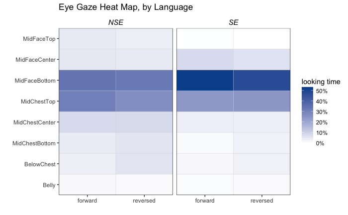

```r
ggplot(heatmap_kids, aes(x = direction, y = aoi)) +
  geom_tile(aes(fill=percent),color="lightgray",na.rm=TRUE) +
#  scale_fill_viridis(option = "viridis", direction=-1, limits = c(0,.7), labels = percent, name = "looking time") +
    scale_fill_gradient(low = "#ffffff", high = "#08519c", space = "Lab", limits = c(0,.52), labels = percent, name = "looking time", na.value = "grey50") +
  theme_bw() +
  theme(strip.text.x = element_text(size = 11, color = "black", face = "italic"),
        strip.background = element_rect(colour = "white", fill = "white"),
        panel.grid.major = element_line(color = "white")) +
  facet_grid(. ~ lang) +
  ylab("") + xlab("") + ggtitle("Eye Gaze Heat Map, by Language") +
  scale_y_discrete(expand=c(0,0)) +
  scale_x_discrete(expand = c(0,0))
```

```r
# All Data
#Here's all AOI data.
kids %>%
  ungroup() %>%
  group_by(lang, name, direction, aoi) %>%
  summarise(percent = mean(percent, na.rm=TRUE)) %>%
  group_by(lang, direction, aoi) %>%
  summarise(percent = mean(percent, na.rm=TRUE)) %>%
  openxlsx::write.xlsx("~/Desktop/kids_by_direction.xlsx")
kids %>%
  ungroup() %>%
  group_by(lang, name, direction, aoi) %>%
  summarise(percent = mean(percent, na.rm=TRUE)) %>%
  group_by(lang, direction, aoi) %>%
  summarise(percent = mean(percent, na.rm=TRUE)) %>%
  group_by(lang, aoi) %>%
  summarise(percent = mean(percent, na.rm=TRUE)) %>%
  openxlsx::write.xlsx("~/Desktop/kids_collapsed.xlsx")
```

# Discussion

No big changes from the ICSLA abstract. Good!

The interpretation here is that:

That doesn’t mean both groups of children don’t care about reversal. On the contrary. We can hypothesize that SE kids have efficient gaze behavior and are resilient to reversal; while NSE kids already are “inefficient” and changing the video stimulus isn’t going to help. But how do we test that? Maybe let’s look at within-subject variation.

# Correlations

Let’s try correlations.

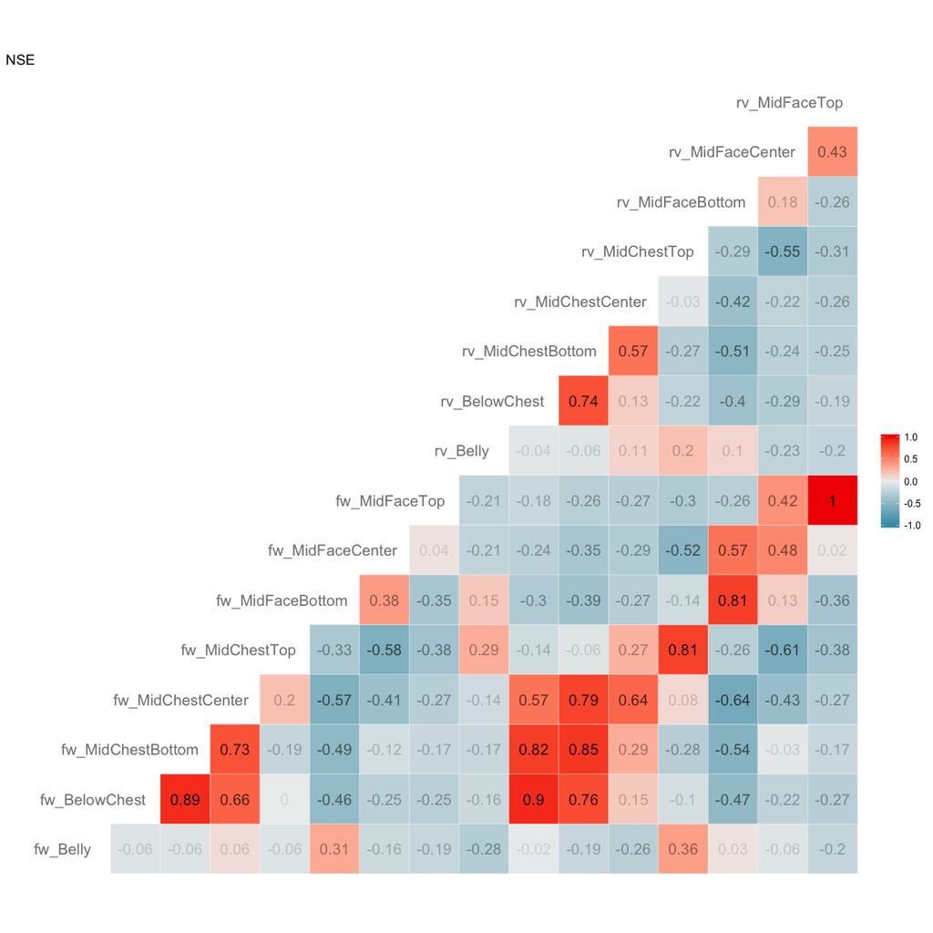

```r
# Let's try correlations
kids_nse <- kids %>%
  filter(aoi %in% midline) %>%
  filter(lang == "NSE") %>%
  group_by(name, direction, aoi) %>%
  summarise(percent = mean(percent)) %>%
  ungroup() %>%
  mutate(direction = case_when(
    direction == "forward" ~ "fw",
    direction == "reversed" ~ "rv"
  )) %>%
  unite(aoi2, direction, aoi, sep = "_") %>%
  spread(aoi2, percent) %>%
  select(-name)
kids_se <- kids %>%
  filter(aoi %in% midline) %>%
  filter(lang == "SE") %>%
  group_by(name, direction, aoi) %>%
  summarise(percent = mean(percent)) %>%
  ungroup() %>%
  mutate(direction = case_when(
    direction == "forward" ~ "fw",
    direction == "reversed" ~ "rv"
  )) %>%
  unite(aoi2, direction, aoi, sep = "_") %>%
  spread(aoi2, percent) %>%
  select(-name)
ggcorr(kids_nse, label = TRUE, label_size = 5, label_round = 2, label_alpha = TRUE, hjust = 0.9, size = 5, color = "grey50", layout.exp = 1) + ggtitle("NSE")
```

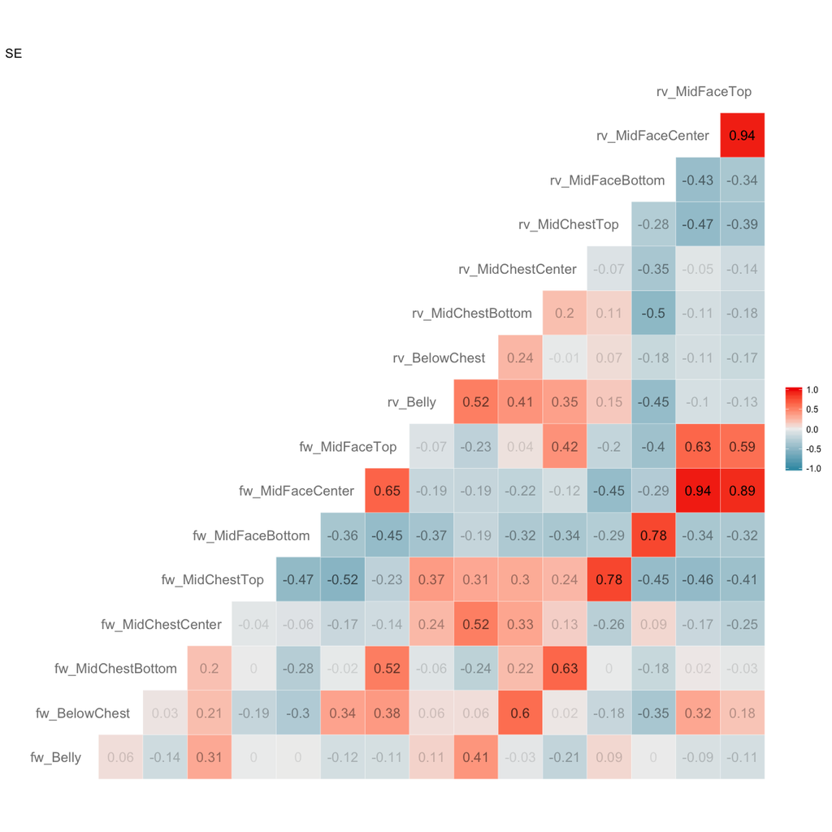

```r
ggcorr(kids_se, label = TRUE, label_size = 5, label_round = 2, label_alpha = TRUE, hjust = 0.9, size = 5, color = "grey50", layout.exp = 1) + ggtitle("SE")
```

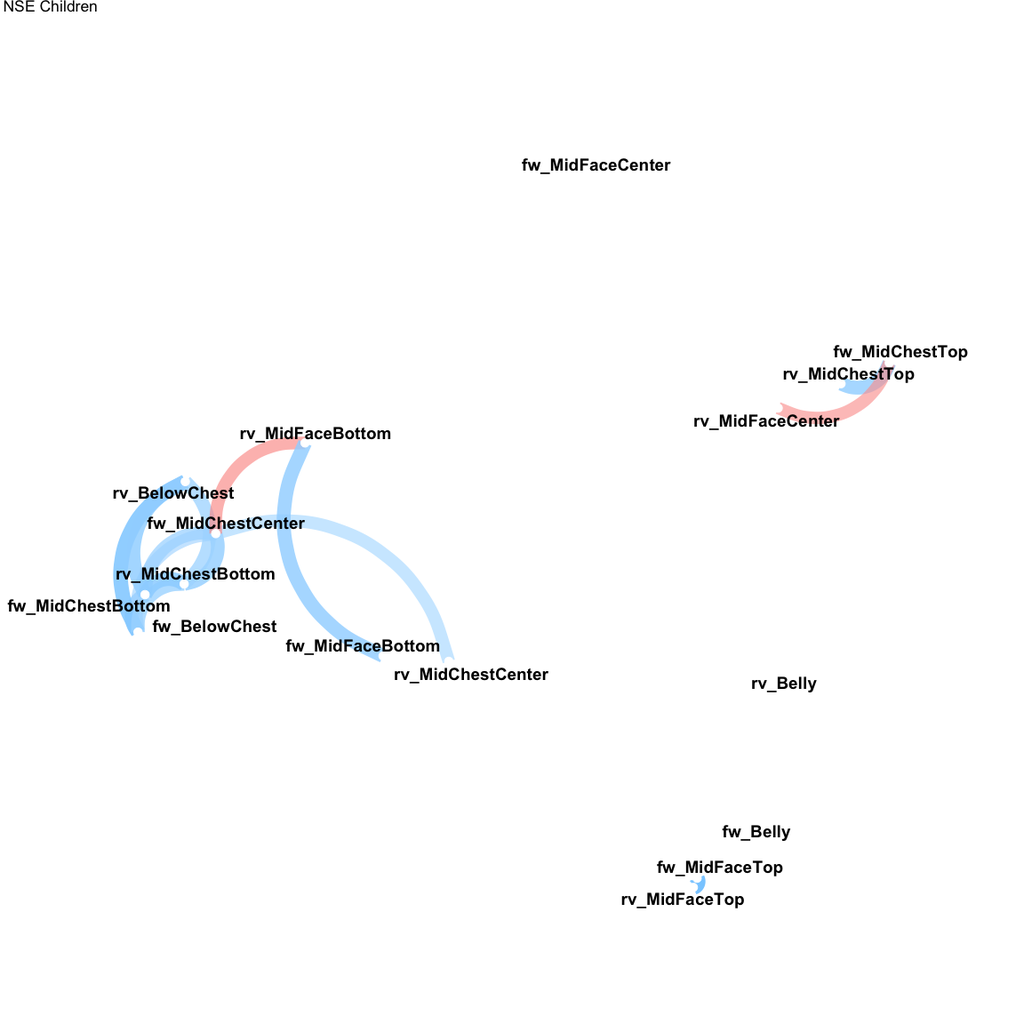

```r
library(corrr)
kids_nse %>% correlate() %>% network_plot(min_cor=0.6) + ggtitle("NSE Children")
```

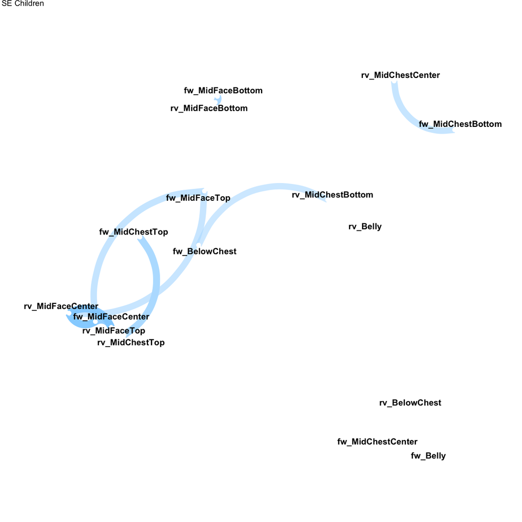

```r
kids_se %>% correlate() %>% network_plot(min_cor=0.6) + ggtitle("SE Children")
```

# XY Space Data

We’ll load the data from the `childxydata.feather` file made in 06rawxydata.Rmd. So any new kids, please run the first code block in 06 to include it. Then we’ll keep all the kids we also have in the AOI data group.

```r
included <- kids %>%
  ungroup() %>%
  select(name) %>%
  distinct() %>%
  unlist()
xydata <- read_feather("../Child Data/childxydata.feather") %>%
  rename(name = participant) %>%
  filter(name %in% included)
# Get ages
ages <- read_csv("childrenages.csv") %>%
  rename(name = participant)
xydata <- xydata %>% left_join(ages, by = "name") %>%
  mutate(age = age*12) %>%
  mutate(agegroup = case_when(
    age <= 8.99 ~ "younger",
    age >= 9.0 & age < 15 ~ "older"
  )) %>%
  mutate(language = case_when(
    language == "EnglishExposed" ~ "NSE",
    language == "SignLanguageExposed" ~ "SE"
  )) %>%
  rename(lang = language) %>%
  select(name, group, gender, lang, condition, mark, trial, repetition, x, y, age, agegroup) %>%
  separate(condition, into = c("story", "clip", "direction")) %>%
  unite("story", c("story", "clip")) %>%
  mutate(direction = case_when(
    direction == "ER" ~ "reversed",
    direction == "FW" ~ "forward"
  )) %>%
  mutate(name = factor(name),
         group = factor(group),
         gender = factor(gender),
         lang = factor(lang),
         story = factor(story),
         direction = factor(direction),
         mark = factor(mark),
         trial = factor(trial),
         repetition = factor(repetition),
         agegroup = factor(agegroup))
```

## Overall Looking

Let’s check that we have no significant group or condition differences in terms of valid (not empty) data points collected. This is same as “Global Looking” we have above, really, but w raw xy data.

```r
xy_overall <- xydata %>%
  filter(!is.na(x)) %>%
  group_by(name, age, lang, direction, story, repetition) %>%
  summarise(data_points = n()) # gets total looking percent for each trial for each baby
# Table of means
xy_overall %>%
  group_by(name, lang, direction) %>%
  summarise(data_points = mean(data_points)) %>% # get average looking percent for each baby
  group_by(lang, direction) %>%
  summarise(mean_data_points = mean(data_points),
            count = n(),
            sd = sd(data_points),
            se = sd/sqrt(count)) %>%
  select(-sd) %>%
  print()
```

| lang | direction | mean_data_points | count | se |
| --- | --- | --- | --- | --- |
| NSE | forward | 622.1135 | 15 | 47.51696 |
| NSE | reversed | 698.1647 | 15 | 51.79825 |
| SE | forward | 689.3280 | 20 | 49.55425 |
| SE | reversed | 662.0953 | 20 | 38.39978 |

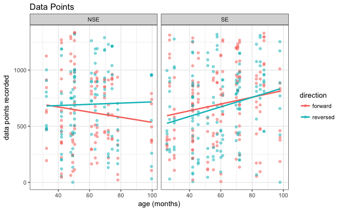

```r
ggplot(xy_overall, aes(x = age, y = data_points, color = direction, fill = direction)) +
  geom_jitter(alpha = 0.5) +
  facet_grid(. ~ lang) +
  geom_smooth(method = "lm", se = FALSE) +
  ggtitle("Data Points") +
  xlab("age (months)") +
  ylab("data points recorded") +
  theme_bw()
```

```r
overall_xy_lm <- lmer(data_points ~ age + lang * direction + (direction|name) + (direction|story), data = xy_overall)
summary(overall_xy_lm)
```

```
Linear mixed model fit by REML. t-tests use Satterthwaite's method ['lmerModLmerTest']
Formula: data_points ~ age + lang * direction + (direction | name) + (direction |      story)
   Data: xy_overall

REML criterion at convergence: 7516.2

Scaled residuals:
    Min      1Q  Median      3Q     Max
-3.0141 -0.5798  0.1909  0.7325  2.2753

Random effects:
 Groups   Name              Variance  Std.Dev. Corr
 name     (Intercept)       1.896e+04 137.6804
          directionreversed 5.468e-02   0.2338 1.00
 story    (Intercept)       4.170e+04 204.1974
          directionreversed 9.717e+03  98.5770 -0.44
 Residual                   6.768e+04 260.1533
Number of obs: 535, groups:  name, 35; story, 8

Fixed effects:
                         Estimate Std. Error      df t value Pr(>|t|)
(Intercept)               525.457    117.894  29.272   4.457 0.000112 ***
age                         2.465      1.397  32.977   1.765 0.086892 .
langSE                      5.896     57.877  32.089   0.102 0.919493
directionreversed         -17.944     49.949  12.211  -0.359 0.725547
langSE:directionreversed   10.156     47.247 487.661   0.215 0.829889
---
Signif. codes:  0 ‘***’ 0.001 ‘**’ 0.01 ‘*’ 0.05 ‘.’ 0.1 ‘ ’ 1

Correlation of Fixed Effects:
            (Intr) age    langSE drctnr
age         -0.697
langSE      -0.278 -0.009
dirctnrvrsd -0.297 -0.002  0.227
lngSE:drctn  0.114  0.005 -0.406 -0.552
```

```r
#ggcoef(overall_xy_lm)
```

## XY Data LMMs

Now we’re going to run LMMs on babies’ raw:

- horizontal spread (middle 50% of x data; xIQR)
- vertical spread (middle 50% of y data; yIQR)
- viewing area (A = middle-x * middle-y; area)

```r
xydata <- xydata %>%
  group_by(name,trial) %>%
  slice(30:n())
iqr <- xydata %>%
  group_by(name, age, lang, story, direction, trial) %>%
  summarise(xIQR = IQR(x,na.rm=TRUE),
                   yIQR = IQR(y,na.rm=TRUE),
                   xmed = median(x, na.rm=TRUE),
                   ymed = median(y, na.rm=TRUE),
                   area = xIQR*yIQR)
head(iqr,20)
```

| name | age | lang | story | direction | trial | xIQR | yIQR | xmed | ymed | area |
| --- | --- | --- | --- | --- | --- | --- | --- | --- | --- | --- |
| Ab07ov09_32m | 32.4 | NSE | Cinderella_1 | reversed | 2 | 37.00 | 40.00 | 512.0 | 266.0 | 1480.000 |
| Ab07ov09_32m | 32.4 | NSE | Cinderella_1 | reversed | 15 | 22.00 | 36.00 | 537.0 | 270.0 | 792.000 |
| Ab07ov09_32m | 32.4 | NSE | Cinderella_2 | reversed | 6 | 59.00 | 33.75 | 550.0 | 250.0 | 1991.250 |
| Ab07ov09_32m | 32.4 | NSE | Cinderella_2 | reversed | 12 | 53.00 | 64.00 | 532.0 | 286.0 | 3392.000 |
| Ab07ov09_32m | 32.4 | NSE | KingMidas_1 | forward | 10 | 37.00 | 50.00 | 504.0 | 340.0 | 1850.000 |
| Ab07ov09_32m | 32.4 | NSE | KingMidas_1 | forward | 13 | 20.00 | 106.00 | 511.0 | 322.0 | 2120.000 |
| Ab07ov09_32m | 32.4 | NSE | KingMidas_2 | forward | 1 | 35.25 | 75.00 | 527.0 | 283.0 | 2643.750 |
| Ab07ov09_32m | 32.4 | NSE | KingMidas_2 | forward | 5 | 33.00 | 32.00 | 554.0 | 319.0 | 1056.000 |
| Ab07ov09_32m | 32.4 | NSE | RedRiding_1 | reversed | 8 | 28.00 | 63.00 | 553.0 | 267.0 | 1764.000 |
| Ab07ov09_32m | 32.4 | NSE | RedRiding_1 | reversed | 11 | 49.00 | 25.00 | 520.0 | 261.0 | 1225.000 |

[output cut: 10 more lines]

### Middle X

```r
xiqr_mean <- iqr %>%
  group_by(lang, direction, name) %>%
  summarise(xIQR = mean(xIQR, na.rm = T)) %>% # gets average looking percent for each baby
  group_by(lang, direction) %>%
  summarise(mean_xIQR = mean(xIQR), # gets group averages
            count = n(),
            sd = sd(xIQR),
            se = sd/sqrt(count)) %>%
  select(-sd) %>%
  print()
```

| lang | direction | mean_xIQR | count | se |
| --- | --- | --- | --- | --- |
| NSE | forward | 34.39246 | 15 | 3.544055 |
| NSE | reversed | 37.44058 | 15 | 2.586100 |
| SE | forward | 33.34821 | 20 | 2.771131 |
| SE | reversed | 34.28728 | 20 | 3.118947 |

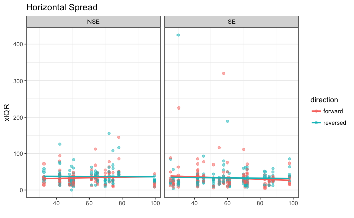

```r
# Plot
ggplot(iqr, aes(x = age, y = xIQR, color = direction, fill = direction)) +
  geom_jitter(alpha = 0.5) +
  geom_smooth(method = "lm", se = FALSE) +
  theme_bw() +
  theme(panel.grid.major.x = element_blank()) +
  facet_grid(. ~ lang) +
  ggtitle("Horizontal Spread") +
  xlab("") +
  ylab("xIQR")
```

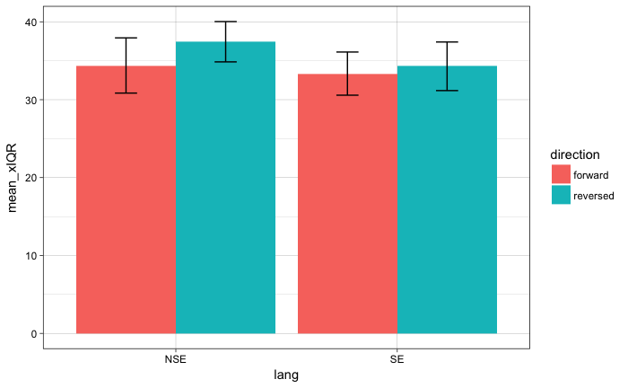

```r
ggplot(xiqr_mean, aes(x = lang, y = mean_xIQR, fill = direction)) +
  geom_bar(stat = "identity", position = position_dodge()) +
  geom_errorbar(aes(ymin = mean_xIQR-se, ymax = mean_xIQR+se), position = position_dodge(0.9), width = 0.2) +
  theme_linedraw()
```

```r
xiqr_lm <- lmer(xIQR ~ age + lang * direction + (1|name) + (1|story), data = iqr)
summary(xiqr_lm)
```

```
Linear mixed model fit by REML. t-tests use Satterthwaite's method ['lmerModLmerTest']
Formula: xIQR ~ age + lang * direction + (1 | name) + (1 | story)
   Data: iqr

REML criterion at convergence: 5145.4

Scaled residuals:
    Min      1Q  Median      3Q     Max
-1.3232 -0.4314 -0.1666  0.1539 12.5401

Random effects:
 Groups   Name        Variance Std.Dev.
 name     (Intercept)  62.388   7.899
 story    (Intercept)   8.698   2.949
 Residual             878.268  29.636
Number of obs: 534, groups:  name, 35; story, 8

Fixed effects:
                          Estimate Std. Error        df t value Pr(>|t|)
(Intercept)               37.50826    6.90369  39.33107   5.433  3.1e-06 ***
age                       -0.05562    0.09857  32.45361  -0.564    0.576
langSE                    -0.93298    4.55974  69.15306  -0.205    0.838
directionreversed          3.17802    3.95955 434.71975   0.803    0.423
langSE:directionreversed  -2.66564    5.25874 457.71103  -0.507    0.612
---
Signif. codes:  0 ‘***’ 0.001 ‘**’ 0.01 ‘*’ 0.05 ‘.’ 0.1 ‘ ’ 1

Correlation of Fixed Effects:
            (Intr) age    langSE drctnr
age         -0.853
langSE      -0.389  0.012
dirctnrvrsd -0.287 -0.002  0.439
lngSE:drctn  0.212  0.007 -0.572 -0.759
```

```r
#ggcoef(xiqr_lm)
```

### Middle Y

```r
yiqr_mean <- iqr %>%
  group_by(lang, direction, name) %>%
  summarise(yIQR = mean(yIQR, na.rm = T)) %>% # gets average looking percent for each baby
  group_by(lang, direction) %>%
  summarise(mean_yIQR = mean(yIQR), # gets group averages
            count = n(),
            sd = sd(yIQR),
            se = sd/sqrt(count)) %>%
  select(-sd) %>%
  print()
```

| lang | direction | mean_yIQR | count | se |
| --- | --- | --- | --- | --- |
| NSE | forward | 52.36627 | 15 | 5.288509 |
| NSE | reversed | 63.29970 | 15 | 8.136185 |
| SE | forward | 42.05826 | 20 | 4.487584 |
| SE | reversed | 42.75429 | 20 | 4.930494 |

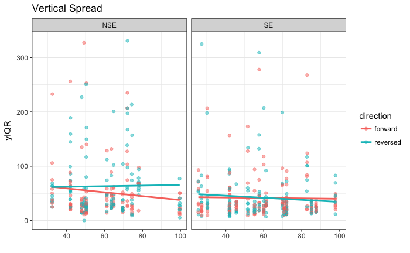

```r
# Plot
ggplot(iqr, aes(x = age, y = yIQR, color = direction, fill = direction)) +
  geom_jitter(alpha = 0.5) +
  geom_smooth(method = "lm", se = FALSE) +
  theme_bw() +
  theme(panel.grid.major.x = element_blank()) +
  facet_grid(. ~ lang) +
  ggtitle("Vertical Spread") +
  xlab("") +
  ylab("yIQR")
```

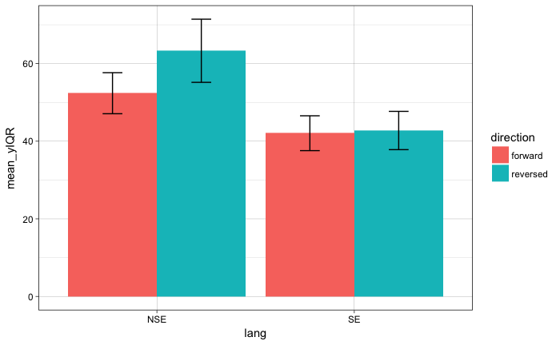

```r
ggplot(yiqr_mean, aes(x = lang, y = mean_yIQR, fill = direction)) +
  geom_bar(stat = "identity", position = position_dodge()) +
  geom_errorbar(aes(ymin = mean_yIQR-se, ymax = mean_yIQR+se), position = position_dodge(0.9), width = 0.2) +
  theme_linedraw()
```

```r
yiqr_lm <- lmer(yIQR ~ age + lang * direction + (1|name) + (1|story), data = iqr)
summary(yiqr_lm)
```

```
Linear mixed model fit by REML. t-tests use Satterthwaite's method ['lmerModLmerTest']
Formula: yIQR ~ age + lang * direction + (1 | name) + (1 | story)
   Data: iqr

REML criterion at convergence: 5653.8

Scaled residuals:
    Min      1Q  Median      3Q     Max
-1.5596 -0.5064 -0.2414  0.1097  5.9864

Random effects:
 Groups   Name        Variance Std.Dev.
 name     (Intercept)  300.671 17.340
 story    (Intercept)    9.835  3.136
 Residual             2251.601 47.451
Number of obs: 534, groups:  name, 35; story, 8

Fixed effects:
                         Estimate Std. Error       df t value Pr(>|t|)
(Intercept)               59.0444    13.0515  37.0017   4.524 6.07e-05 ***
age                       -0.1151     0.1903  32.8125  -0.605   0.5493
langSE                   -10.5298     8.3370  56.5536  -1.263   0.2118
directionreversed         10.9449     6.2896 400.3400   1.740   0.0826 .
langSE:directionreversed -10.0338     8.3652 432.0794  -1.199   0.2310
---
Signif. codes:  0 ‘***’ 0.001 ‘**’ 0.01 ‘*’ 0.05 ‘.’ 0.1 ‘ ’ 1

Correlation of Fixed Effects:
            (Intr) age    langSE drctnr
age         -0.872
langSE      -0.378  0.015
dirctnrvrsd -0.241 -0.001  0.381
lngSE:drctn  0.178  0.006 -0.497 -0.755
```

```r
#ggcoef(yiqr_lm)
```

### Viewing Area

```r
area_mean <- iqr %>%
  group_by(lang, direction, name) %>%
  summarise(area = mean(area, na.rm = T)) %>% # gets average looking percent for each baby
  group_by(lang, direction) %>%
  summarise(area_mean = mean(area), # gets group averages
            count = n(),
            sd = sd(area),
            se = sd/sqrt(count)) %>%
  select(-sd) %>%
  print()
```

| lang | direction | area_mean | count | se |
| --- | --- | --- | --- | --- |
| NSE | forward | 2037.211 | 15 | 337.7487 |
| NSE | reversed | 2886.616 | 15 | 552.0810 |
| SE | forward | 2189.776 | 20 | 621.9844 |
| SE | reversed | 1867.996 | 20 | 394.2072 |

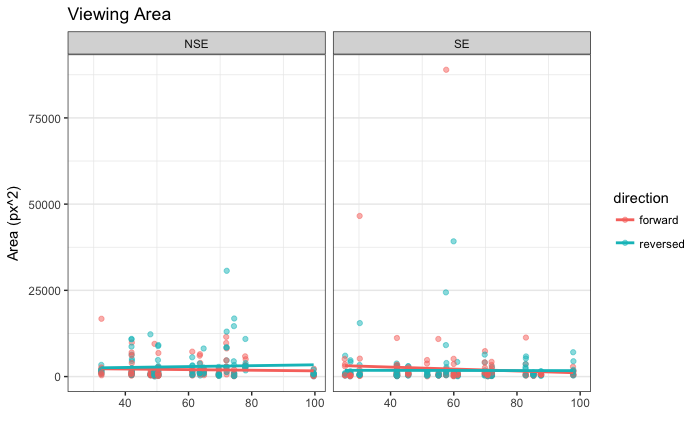

```r
# Plot
ggplot(iqr, aes(x = age, y = area, color = direction, fill = direction)) +
  geom_jitter(alpha = 0.5) +
  geom_smooth(method = "lm", se = FALSE) +
  theme_bw() +
  theme(panel.grid.major.x = element_blank()) +
  facet_grid(. ~ lang) +
  ggtitle("Viewing Area") +
  xlab("") +
  ylab("Area (px^2)")
```

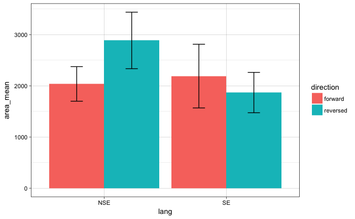

```r
ggplot(area_mean, aes(x = lang, y = area_mean, fill = direction)) +
  geom_bar(stat = "identity", position = position_dodge()) +
  geom_errorbar(aes(ymin = area_mean-se, ymax = area_mean+se), position = position_dodge(0.9), width = 0.2) +
  theme_linedraw()
```

```r
area_lm <- lmer(area ~ age + lang * direction + (1|name) + (1|story), data = iqr)
summary(area_lm)
```

```
Linear mixed model fit by REML. t-tests use Satterthwaite's method ['lmerModLmerTest']
Formula: area ~ age + lang * direction + (1 | name) + (1 | story)
   Data: iqr

REML criterion at convergence: 10618.2

Scaled residuals:
    Min      1Q  Median      3Q     Max
-1.0106 -0.2805 -0.1782 -0.0233 15.8517

Random effects:
 Groups   Name        Variance Std.Dev.
 name     (Intercept)  1710669 1307.9
 story    (Intercept)    31917  178.7
 Residual             27599545 5253.5
Number of obs: 534, groups:  name, 35; story, 8

Fixed effects:
                          Estimate Std. Error        df t value Pr(>|t|)
(Intercept)               2544.897   1172.877    39.578   2.170   0.0361 *
age                         -8.878     16.888    33.501  -0.526   0.6026
langSE                     175.276    786.530    72.890   0.223   0.8243
directionreversed          881.472    691.160   362.380   1.275   0.2030
langSE:directionreversed -1285.287    920.306   402.617  -1.397   0.1633
---
Signif. codes:  0 ‘***’ 0.001 ‘**’ 0.01 ‘*’ 0.05 ‘.’ 0.1 ‘ ’ 1

Correlation of Fixed Effects:
            (Intr) age    langSE drctnr
age         -0.860
langSE      -0.393  0.012
dirctnrvrsd -0.295 -0.001  0.442
lngSE:drctn  0.217  0.007 -0.580 -0.752
```

```r
#ggcoef(area_lm)
```

## Plotting Viewing Area

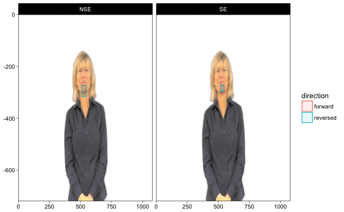

```r
medians <- iqr %>%
  group_by(name,lang,direction) %>%
  summarise(xIQR = median(xIQR,na.rm=TRUE),
                   yIQR = median(yIQR,na.rm=TRUE),
                   xmed = median(xmed,na.rm=TRUE),
                   ymed = median(ymed,na.rm=TRUE)) %>%
  group_by(lang,direction) %>%
  summarise(xIQR = median(xIQR,na.rm=TRUE),
                   yIQR = median(yIQR,na.rm=TRUE),
                   x = median(xmed,na.rm=TRUE),
                   y = median(ymed,na.rm=TRUE)) %>%
  mutate(y = y*-1,
         xmin = x-(xIQR/2),
         xmax = x+(xIQR/2),
         ymin = y-(yIQR/2),
         ymax = y+(yIQR/2))
img <- png::readPNG("cindy.png")
g <- grid::rasterGrob(img, interpolate=TRUE, width=unit(1,"npc"), height=unit(1,"npc"))
ggplot(medians, aes(fill=direction,color=direction)) +
  annotation_custom(g, xmin=-Inf, xmax=Inf, ymin=-Inf, ymax=Inf) +
  geom_rect(aes(xmin=xmin,ymin=ymin,xmax=xmax,ymax=ymax),alpha=.1) +
  theme_linedraw() +
  scale_x_continuous(limits = c(0,1080), expand = c(0, 0)) +
  scale_y_continuous(limits = c(-720,0), expand = c(0, 0)) +
  facet_wrap("lang")
```